# Notes2 - Reproducible Research

Linda Kukolich

January 15, 2015

# Coding Standards in R

1. Use text files and a text editor
2. Indent your code
3. Limit the width of your code to 80 columns
4. Limit the length of functions

*Seriously? Nothing on “Do not repeat code” or “use variable names that help explain the code”?*

# Markdown

> “Markdown is a text-to-HTML conversion tool for web writers. It allows you to write using an easy-to-read, easy-to-write plain text format, and then convert it to structurally valid XHTML (or HTML).”

**John Gruber, creator of Markdown**

Aaron Schwartz is also a creator of Markdown

```
# Level 1 header
## Level 2
### Level 3
```

# Level 1 header

## Level 2

### Level 3

```
* *italics*
* **Bold**
```

- *italics*
- **Bold**

```
- also a list
- with stuff
    a. this is also an ordered list
    b. with lower-alpha as a type
```

- also a list
- with stuff
  1. this is also an ordered list
  2. with lower-alpha as a type

```
[linkText](http://www.google.com)
```

# R Markdown

Allows mixing in blocks of R code for documentation and to generate plots.

Rmd becomes md becomes html

# knitr

## Literate Statistical Programming

- original idea from Donald Knuth
- An article is a stream of text and code.
- Analysis code is divided into text and code chunks
- Presentation code formats results (table, plots)
- Article text explains what is going on
- Literate programs are woven to produce human-readable documents and tangled to produce machine readable documents
- Literate programming is a general concept with needs
  - a documentation language
  - a programming language
- **Sweave** by Friedrich Leisch used LaTeX and R
- **knitr** supports a variety of documentation languages (plot R)
  - written by Yihui Xie (while at Iowa State)
  - Supports RMarkdown, LaTeX, and HTML
  - can export to PDF, HTML
  - RStudio support

## How do I make my work reproducible?

- Decide to do it from (ideally from the beginning)
- Keep track of things (use version control to save intermediate state)
- Use software whose operation can be coded
- Don’t save output
- Save data in non-proprietary formats

## Pros and Cons

- Pros
  - Store text and code all in one place
  - Data, results are automatically updated to reflect external changes
  - Code is live, an automatic regression test while building a document
- Cons
  - Text and code all in one place
  - If there is a lot of code, this can be hard to read
  - Can substantially slow down process of documents
- Things knitr is good for
  - Manuals
  - Short/medium-length technical documents
  - Tutorials
  - reports (especially if generated periodically)
  - Data preprocessing documents/summaries
- Things knitr is NOT good for
  - Very long reserch articles
  - complex time-consuming computations
  - Documents that require precise formatting

```
library(knitr)
setwd(<working directory>)
knit2html("document.Rmd")
browseURL("document.html")
```

## Cool stuff

{r simulation, echo = FALSE, results=“hide”} to supress not just the source code, but also the prints and possibly the plots

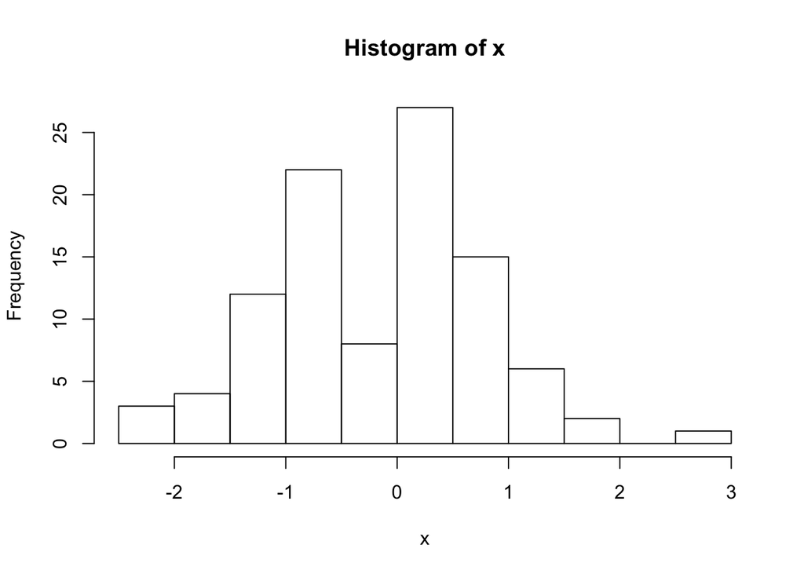

# Peer Assessment 1